# Отчёт по лабораторной работе №7.

Дискретное логарифмирование в конечном поле

Коне Сирики

Российский университет дружбы народов, Москва, Россия

Объединённый институт ядерных исследований, Дубна, Россия

20 декабря 2024

# Информация

## Докладчик

- Коне Сирики
- Студент физмат
- профессор кафедры прикладной информатики и теории вероятностей
- Российский университет дружбы народов
- konesirisil@yandex.ru
- https://github.com/skone19

## Цели и задачи работы

данной лабораторной работы является краткое ознакомление с задачей дискретного логарифмирования и *ρ*-методом Полларда для её решения, а также его последующая программная реализация.

Рассмотреть и реализовать на языке программирования Python *ρ*-метод Полларда для задачи дискретного логарифмирования.

# Теоретическое введение

## Задача дискретного логарифмирования

Для конечного поля 𝔽<sub>*p*</sub> (в частности, в простейшем и важнейшем случае ℤ<sub>*p*</sub>*, где *p* – большое простое число) определяется следующим образом: при заданных ненулевых *a*, *b* ∈ 𝔽<sub>*p*</sub> найти такое целое *x*, что:

*a*<sup>*x*</sup> ≡ *b* ∈ 𝔽<sub>*p*</sub>, или *a*<sup>*x*</sup> ≡ *b* (mod *p*).

Пусть число *a* также имеет порядок *r*, то есть *a*<sup>*r*</sup> ≡ 1 (mod *p*).

## *ρ*-метод Полларда для дискретного логарифмирования

Идея *ρ*-метода Полларда, как и аналогичного метода факторизации, в построении последовательности итеративных значений функции *f*, в которой требуется найти цикл.

Для этого, как и ранее, используем алгоритм “черепахи и зайца” Флойда: к одному значению, *c*, на каждом шаге будем применять функции единожды, к другому, *d*, – дважды, пока их значения не совпадут и мы не сможем их приравнять.

## *ρ*-метод Полларда. Шаг 1

- Зададим начальные значения *c* и *d*. Пусть *c* = *d* ≡ *a*<sup>*u*<sub>0</sub></sup>*b*<sup>*v*<sub>0</sub></sup> (mod *p*), где *u*<sub>0</sub>, *v*<sub>0</sub> случайные целые числа.
- Поскольку по условию *b* ≡ *a*<sup>*x*</sup> (mod *p*), можно записать *c* ≡ *a*<sup>*u*<sub>0</sub></sup>(*a*<sup>*x*</sup>)<sup>*v*<sub>0</sub></sup> (mod *p*) ≡ *a*<sup>*u*<sub>0</sub> + *v*<sub>0</sub>*x*</sup> (mod *p*). Тогда log<sub>*a*</sub>*c* (mod *p*) = *u*<sub>0</sub> + *v*<sub>0</sub>*x*.
- Таким образом, логарифмы *c* и *d* по основанию *a* могут быть представлены линейно.

## *ρ*-метод Полларда. Определение функции *f*

Зададим отображение *f*, обладающее а) сжимающими свойствами и б) вычислимостью логарифма.

$$f(c) = \begin{cases} ac, &
\text{при}\ c < \frac{p}{2} \\ bc, & \text{при}\ c \ge
\frac{p}{2} \end{cases}$$

*f*(*c*) ≡ (*a*<sup>*u*</sup>*b*<sup>*v*</sup>)*a* (mod *p*)≡ *a*<sup>(*u* + 1) + *v**x*</sup> (mod *p*), и тогда log<sub>*a*</sub>*f*(*c*) = (*u* + 1) + *v**x* = log<sub>*a*</sub>*c* + 1.

*f*(*c*) ≡ (*a*<sup>*u*</sup>*b*<sup>*v*</sup>)*b* (mod *p*)≡ *a*<sup>*u* + (*v* + 1)*x*</sup> (mod *p*), и тогда log<sub>*a*</sub>*f*(*c*) = *u* + (*v* + 1)*x* = log<sub>*a*</sub>*c* + *x*.

## *ρ*-метод Полларда. Шаг 2

- Выполнять *c* ← *f*(*c*) (mod *p*), *d* ← *f*(*f*(*d*)) (mod *p*), вычисляя при этом log<sub>*a*</sub>*c* и log<sub>*a*</sub>*d* как линейные функции от *x* по модулю *r*, пока не получим равенство *c* ≡ *d* (mod *p*).

## *ρ*-метод Полларда. Шаг 3. Решение сравнения

Приравниваем линейные представления логарифмов и получаем: *u*<sub>*i*</sub><sup>*c*</sup> + *v*<sub>*i*</sub><sup>*c*</sup>*x* ≡ *u*<sub>*i*</sub><sup>*d*</sup> + *v*<sub>*i*</sub><sup>*d*</sup>*x* (mod *r*).

Приведем подобные слагаемые: *v**x* ≡ *u* (mod *r*), где *v* = *v*<sub>*i*</sub><sup>*c*</sup> − *v*<sub>*i*</sub><sup>*d*</sup>, *u* = *u*<sub>*i*</sub><sup>*d*</sup> − *u*<sub>*i*</sub><sup>*c*</sup>.

Чтобы решить такое сравнение, нужно найти и умножить на него левую и правую части сравнения: *x* ≡ *u**v*<sup>−1</sup> (mod *r*).

## *ρ*-метод Полларда. Шаг 3. Обратный элемент

С помощью расширенного алгоритма Евклида получим линейное представление НОД, равного единице: *e*<sub>*v*</sub>*v* + *e*<sub>*r*</sub>*r* = 1, что эквивалентно *e*<sub>*v*</sub>*v* − 1 = −*e*<sub>*r*</sub>*r*, или (*e*<sub>*v*</sub>*v* − 1) | *r*, или *e*<sub>*v*</sub>*v* ≡ 1 (mod *r*). Таким образом *v*<sup>−1</sup> = *e*<sub>*v*</sub>.

Если же НОД не равен единице, то мы предполагаем, что *g**c**d* = НОД(*v*, *r*) = НОД(*v*, *u*, *r*). Тогда сравнение можно поделить на *g**c**d*, и получим $\frac{v}{gcd} x \equiv \frac{u}{gcd} \pmod{\frac{r}{gcd}}$.

# Ход выполнения и результаты

## Реализация (1 / 4)

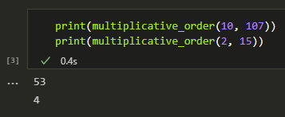

Примеры нахождения порядка числа *a* по модулю *n*

```python
import math; import numpy as np
def multiplicative_order(a, n):
    k = 1; flag = True # начнем перебор с единицы
    while flag:
        if (a ** k - 1) % n == 0: flag = False
        else: k += 1
    return k
```

## Реализация (2 / 4)

```python
def euclidean_algorithm_extended(a, b): <...> return (d, x_r, y_r)

def solve_congruence(c, d, p):
    (k_1, b_1) = c; (k_2, b_2) = d # получаем коэффициенты
    k = k_1 - k_2; b = b_2 - b_1 # kx = b (mod p)
    (gcd, k_inverse, _) = euclidean_algorithm_extended(k, p)
    if gcd == 1: # если k и p - взаимно простые..
        return (b * k_inverse) % p
    else: # иначе
        k = int(k / gcd); b = int(b / gcd) # делим сравнение на gcd
        (_,k_inverse,_) = euclidean_algorithm_extended(k, int(p/gcd))

        return (b * k_inverse) % p
```

## Реализация (3 / 4)

```python
def pollard_rho_dlog(a, b, p, def0 = True, to_print = False):
    r = multiplicative_order(a, p) # порядок числа а
    half_p = math.floor(p / 2) # p / 2
    f = "({a} * x % {p}) if x < {half} else ({b} * x % {p})"
                       .format(a = a, p = p, half = half_p, b = b)
    (u, v) = (2, 2) if def0 else (np.random.randint(1, half_p),
                                  np.random.randint(1, half_p))
    c = ((a ** u) * (b ** v)) % p    #
    d = c                            # шаг 1
    (k_c, l_c) = (k_d, l_d) = (u, v) #

    if to_print: <...>
      print("{:^10} | {:^3} + {:^3}x | {:^10} | {:^3} + {:^3}x"
                              .format(c, l_c, k_c, d, l_d, k_d))
```

## Реализация (4 / 4)

```python
    while True:
        x = c
        if x < half_p: l_c += 1
        else: k_c += 1
        c = eval(f); x = d
        if x < half_p: l_d += 1
        else: k_d += 1
        x = eval(f)
        if x < half_p: l_d += 1
        else: k_d += 1
        d = eval(f) <...>
        if c == d: # шаг 3
            result = solve_congruence((k_c, l_c), (k_d, l_d), r)
            if (a ** result - b) % p == 0: return result
            else: return 0
```

## Результаты (1 / 2)

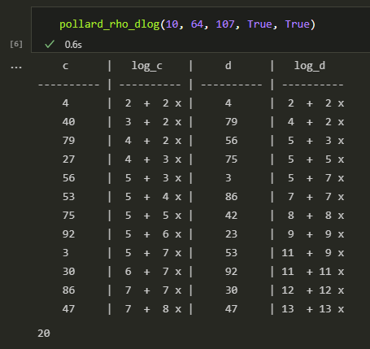

Решение сравнения 10<sup>*x*</sup> ≡ 64 (mod 107)

## Результаты (2 / 2)

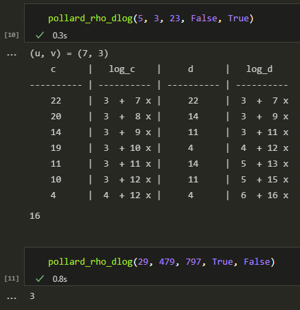

Решение сравнений 5<sup>*x*</sup> ≡ 3 (mod 23) (сверху) и 29<sup>*x*</sup> ≡ 479 (mod 797) (снизу)

## Заключение

Таким образом, была достигнута цель, поставленная в начале лабораторной работы: было проведено краткое знакомство с задачей дискретного логарифмирования и с алгоритмом, реализующим *ρ*-метод Полларда для её решения, после чего алгоритм был успешно реализован на языке программирования **Python**.

Спасибо за внимание